# Final Project - Is crime decreasing in the US according to the FBI Uniform Crime Reporting (UCR) Program

# There are two colums with NA: Rape(revised definition) and Rape(revised definition) rate

We should remove colums with NA

```r
df = select(df, -c(`Rape(revised definition)`,`Rape(revised definition) rate`))
str(df)
```

```
## tibble [20 x 20] (S3: tbl_df/tbl/data.frame)
##  $ Year                                     : chr [1:20] "1997" "1998" "1999" "2000" ...
##  $ Population                               : chr [1:20] "267,783,607" "270,248,003" "272,690,813" "281,421,906" ...
##  $ Violentcrime                             : chr [1:20] "1,636,096" "1,533,887" "1,426,044" "1,425,486" ...
##  $ Violent crime rate                       : chr [1:20] "611.0" "567.6" "523.0" "506.5" ...
##  $ Murder andnonnegligent manslaughter      : chr [1:20] "18,208" "16,974" "15,522" "15,586" ...
##  $ Murder and nonnegligent manslaughter rate: chr [1:20] "6.8" "6.3" "5.7" "5.5" ...
##  $ Rape(legacy definition)                  : chr [1:20] "96,153" "93,144" "89,411" "90,178" ...
##  $ Rape(legacy definition) rate             : chr [1:20] "35.9" "34.5" "32.8" "32.0" ...
##  $ Robbery                                  : chr [1:20] "498,534" "447,186" "409,371" "408,016" ...
##  $ Robbery rate                             : chr [1:20] "186.2" "165.5" "150.1" "145.0" ...
##  $ Aggravated assault                       : chr [1:20] "1,023,201" "976,583" "911,740" "911,706" ...
##  $ Aggravated assault rate                  : chr [1:20] "382.1" "361.4" "334.3" "324.0" ...
##  $ Property crime                           : chr [1:20] "11,558,475" "10,951,827" "10,208,334" "10,182,584" ...
##  $ Property crime rate                      : chr [1:20] "4,316.3" "4,052.5" "3,743.6" "3,618.3" ...
##  $ Burglary                                 : chr [1:20] "2,460,526" "2,332,735" "2,100,739" "2,050,992" ...
##  $ Burglary rate                            : chr [1:20] "918.8" "863.2" "770.4" "728.8" ...
##  $ Larceny-theft                            : chr [1:20] "7,743,760" "7,376,311" "6,955,520" "6,971,590" ...
##  $ Larceny-theft rate                       : chr [1:20] "2,891.8" "2,729.5" "2,550.7" "2,477.3" ...
##  $ Motor vehicle theft                      : chr [1:20] "1,354,189" "1,242,781" "1,152,075" "1,160,002" ...
##  $ Motor vehicle theft rate                 : chr [1:20] "505.7" "459.9" "422.5" "412.2" ...
```

# All colums in dataframe are string. We should change some to integers or numbers

```r
df[["Year"]] = as.integer(df[["Year"]])
df[["Population"]] = as.integer(gsub(",", "", df[["Population"]], fixed = TRUE))
df[["Violentcrime"]] = as.integer(gsub(",", "", df[["Violentcrime"]], fixed = TRUE))
df[["Violent crime rate"]] = as.numeric(df[["Violent crime rate"]])
df[["Murder andnonnegligent manslaughter"]] = as.integer(gsub(",", "", df[["Murder andnonnegligent manslaughter"]], fixed = TRUE))
df[["Murder and nonnegligent manslaughter rate"]] = as.numeric(df[["Murder and nonnegligent manslaughter rate"]])
df[["Rape(legacy definition)"]] = as.integer(gsub(",", "", df[["Rape(legacy definition)"]], fixed = TRUE))
df[["Rape(legacy definition) rate"]] = as.numeric(df[["Rape(legacy definition) rate"]])
df[["Robbery"]] = as.integer(gsub(",", "", df[["Robbery"]], fixed = TRUE))
df[["Robbery rate"]] = as.numeric(df[["Robbery rate"]])
df[["Aggravated assault"]] = as.integer(gsub(",", "", df[["Aggravated assault"]], fixed = TRUE))
df[["Aggravated assault rate"]] = as.numeric(df[["Aggravated assault rate"]])
df[["Property crime"]] = as.integer(gsub(",", "", df[["Property crime"]], fixed = TRUE))
df[["Property crime rate"]] = as.numeric(gsub(",", "", df[["Property crime rate"]], fixed = TRUE))
df[["Burglary"]] = as.integer(gsub(",", "", df[["Burglary"]], fixed = TRUE))
df[["Burglary rate"]] = as.numeric(df[["Burglary rate"]])
df[["Larceny-theft"]] = as.integer(gsub(",", "", df[["Larceny-theft"]], fixed = TRUE))
df[["Larceny-theft rate"]] = as.numeric(gsub(",", "", df[["Larceny-theft rate"]], fixed = TRUE))
df[["Motor vehicle theft"]] = as.integer(gsub(",", "", df[["Motor vehicle theft"]], fixed = TRUE))
df[["Motor vehicle theft rate"]] = as.numeric(df[["Motor vehicle theft rate"]])
```

# Create a table directly from R Markdown

```r
knitr::kable(df, caption = 'Crime in the United States')
```

Crime in the United States

| Year | Population | Violentcrime | Violent crime rate | Murder andnonnegligent manslaughter | Murder and nonnegligent manslaughter rate | Rape(legacy definition) | Rape(legacy definition) rate | Robbery | Robbery rate | Aggravated assault | Aggravated assault rate | Property crime | Property crime rate | Burglary | Burglary rate | Larceny-theft | Larceny-theft rate | Motor vehicle theft | Motor vehicle theft rate |
| --- | --- | --- | --- | --- | --- | --- | --- | --- | --- | --- | --- | --- | --- | --- | --- | --- | --- | --- | --- |
| 1997 | 267783607 | 1636096 | 611.0 | 18208 | 6.8 | 96153 | 35.9 | 498534 | 186.2 | 1023201 | 382.1 | 11558475 | 4316.3 | 2460526 | 918.8 | 7743760 | 2891.8 | 1354189 | 505.7 |
| 1998 | 270248003 | 1533887 | 567.6 | 16974 | 6.3 | 93144 | 34.5 | 447186 | 165.5 | 976583 | 361.4 | 10951827 | 4052.5 | 2332735 | 863.2 | 7376311 | 2729.5 | 1242781 | 459.9 |
| 1999 | 272690813 | 1426044 | 523.0 | 15522 | 5.7 | 89411 | 32.8 | 409371 | 150.1 | 911740 | 334.3 | 10208334 | 3743.6 | 2100739 | 770.4 | 6955520 | 2550.7 | 1152075 | 422.5 |
| 2000 | 281421906 | 1425486 | 506.5 | 15586 | 5.5 | 90178 | 32.0 | 408016 | 145.0 | 911706 | 324.0 | 10182584 | 3618.3 | 2050992 | 728.8 | 6971590 | 2477.3 | 1160002 | 412.2 |
| 2001 | 285317559 | 1439480 | 504.5 | 16037 | 5.6 | 90863 | 31.8 | 423557 | 148.5 | 909023 | 318.6 | 10437189 | 3658.1 | 2116531 | 741.8 | 7092267 | 2485.7 | 1228391 | 430.5 |
| 2002 | 287973924 | 1423677 | 494.4 | 16229 | 5.6 | 95235 | 33.1 | 420806 | 146.1 | 891407 | 309.5 | 10455277 | 3630.6 | 2151252 | 747.0 | 7057379 | 2450.7 | 1246646 | 432.9 |
| 2003 | 290788976 | 1383676 | 475.8 | 16528 | 5.7 | 93883 | 32.3 | 414235 | 142.5 | 859030 | 295.4 | 10442862 | 3591.2 | 2154834 | 741.0 | 7026802 | 2416.5 | 1261226 | 433.7 |
| 2004 | 293656842 | 1360088 | 463.2 | 16148 | 5.5 | 95089 | 32.4 | 401470 | 136.7 | 847381 | 288.6 | 10319386 | 3514.1 | 2144446 | 730.3 | 6937089 | 2362.3 | 1237851 | 421.5 |
| 2005 | 296507061 | 1390745 | 469.0 | 16740 | 5.6 | 94347 | 31.8 | 417438 | 140.8 | 862220 | 290.8 | 10174754 | 3431.5 | 2155448 | 726.9 | 6783447 | 2287.8 | 1235859 | 416.8 |
| 2006 | 299398484 | 1435123 | 479.3 | 17309 | 5.8 | 94472 | 31.6 | 449246 | 150.0 | 874096 | 292.0 | 10019601 | 3346.6 | 2194993 | 733.1 | 6626363 | 2213.2 | 1198245 | 400.2 |
| 2007 | 301621157 | 1422970 | 471.8 | 17128 | 5.7 | 92160 | 30.6 | 447324 | 148.3 | 866358 | 287.2 | 9882212 | 3276.4 | 2190198 | 726.1 | 6591542 | 2185.4 | 1100472 | 364.9 |
| 2008 | 304059724 | 1394461 | 458.6 | 16465 | 5.4 | 90750 | 29.8 | 443563 | 145.9 | 843683 | 277.5 | 9774152 | 3214.6 | 2228887 | 733.0 | 6586206 | 2166.1 | 959059 | 315.4 |
| 2009 | 307006550 | 1325896 | 431.9 | 15399 | 5.0 | 89241 | 29.1 | 408742 | 133.1 | 812514 | 264.7 | 9337060 | 3041.3 | 2203313 | 717.7 | 6338095 | 2064.5 | 795652 | 259.2 |
| 2010 | 309330219 | 1251248 | 404.5 | 14722 | 4.8 | 85593 | 27.7 | 369089 | 119.3 | 781844 | 252.8 | 9112625 | 2945.9 | 2168459 | 701.0 | 6204601 | 2005.8 | 739565 | 239.1 |
| 2011 | 311587816 | 1206005 | 387.1 | 14661 | 4.7 | 84175 | 27.0 | 354746 | 113.9 | 752423 | 241.5 | 9052743 | 2905.4 | 2185140 | 701.3 | 6151095 | 1974.1 | 716508 | 230.0 |
| 2012 | 313873685 | 1217057 | 387.8 | 14856 | 4.7 | 85141 | 27.1 | 355051 | 113.1 | 762009 | 242.8 | 9001992 | 2868.0 | 2109932 | 672.2 | 6168874 | 1965.4 | 723186 | 230.4 |
| 2013 | 316497531 | 1168298 | 369.1 | 14319 | 4.5 | 82109 | 25.9 | 345093 | 109.0 | 726777 | 229.6 | 8651892 | 2733.6 | 1932139 | 610.5 | 6019465 | 1901.9 | 700288 | 221.3 |
| 2014 | 318907401 | 1153022 | 361.6 | 14164 | 4.4 | 84864 | 26.6 | 322905 | 101.3 | 731089 | 229.2 | 8209010 | 2574.1 | 1713153 | 537.2 | 5809054 | 1821.5 | 686803 | 215.4 |
| 2015 | 320896618 | 1199310 | 373.7 | 15883 | 4.9 | 91261 | 28.4 | 328109 | 102.2 | 764057 | 238.1 | 8024115 | 2500.5 | 1587564 | 494.7 | 5723488 | 1783.6 | 713063 | 222.2 |
| 2016 | 323127513 | 1248185 | 386.3 | 17250 | 5.3 | 95730 | 29.6 | 332198 | 102.8 | 803007 | 248.5 | 7919035 | 2450.7 | 1515096 | 468.9 | 5638455 | 1745.0 | 765484 | 236.9 |

# Summary of Data in Data Frame

The statistical summary and nature of the data can be obtained by applying summary() function

```r
print(summary(df))
```

```
##       Year        Population         Violentcrime     Violent crime rate
##  Min.   :1997   Min.   :267783607   Min.   :1153022   Min.   :361.6
##  1st Qu.:2002   1st Qu.:287309833   1st Qu.:1240403   1st Qu.:387.6
##  Median :2006   Median :300509820   Median :1387211   Median :466.1
##  Mean   :2006   Mean   :298634769   Mean   :1352038   Mean   :456.3
##  3rd Qu.:2011   3rd Qu.:312159283   3rd Qu.:1425626   3rd Qu.:496.9
##  Max.   :2016   Max.   :323127513   Max.   :1636096   Max.   :611.0
##  Murder andnonnegligent manslaughter Murder and nonnegligent manslaughter rate
##  Min.   :14164                       Min.   :4.400
##  1st Qu.:15263                       1st Qu.:4.875
##  Median :16092                       Median :5.500
##  Mean   :16006                       Mean   :5.375
##  3rd Qu.:16799                       3rd Qu.:5.700
##  Max.   :18208                       Max.   :6.800
##  Rape(legacy definition) Rape(legacy definition) rate    Robbery
##  Min.   :82109           Min.   :25.90                Min.   :322905
##  1st Qu.:88329           1st Qu.:28.23                1st Qu.:354975
##  Median :91062           Median :31.10                Median :409057
##  Mean   :90690           Mean   :30.50                Mean   :399834
##  3rd Qu.:94378           3rd Qu.:32.33                3rd Qu.:428559
##  Max.   :96153           Max.   :35.90                Max.   :498534
##   Robbery rate   Aggravated assault Aggravated assault rate Property crime
##  Min.   :101.3   Min.   : 726777    Min.   :229.2           Min.   : 7919035
##  1st Qu.:113.7   1st Qu.: 777397    1st Qu.:247.1           1st Qu.: 9040055
##  Median :141.7   Median : 853206    Median :287.9           Median : 9950906
##  Mean   :135.0   Mean   : 845507    Mean   :285.4           Mean   : 9685756
##  3rd Qu.:148.3   3rd Qu.: 895811    3rd Qu.:311.8           3rd Qu.:10348837
##  Max.   :186.2   Max.   :1023201    Max.   :382.1           Max.   :11558475
##  Property crime rate    Burglary       Burglary rate   Larceny-theft
##  Min.   :2451        Min.   :1515096   Min.   :468.9   Min.   :5638455
##  1st Qu.:2896        1st Qu.:2088302   1st Qu.:693.8   1st Qu.:6164429
##  Median :3312        Median :2153043   Median :727.9   Median :6608952
##  Mean   :3271        Mean   :2084819   Mean   :703.2   Mean   :6590070
##  3rd Qu.:3621        3rd Qu.:2191397   3rd Qu.:741.2   3rd Qu.:6985393
##  Max.   :4316        Max.   :2460526   Max.   :918.8   Max.   :7743760
##  Larceny-theft rate Motor vehicle theft Motor vehicle theft rate
##  Min.   :1745       Min.   : 686803     Min.   :215.4
##  1st Qu.:1972       1st Qu.: 735470     1st Qu.:235.3
##  Median :2199       Median :1126274     Median :382.6
##  Mean   :2224       Mean   :1010867     Mean   :343.5
##  3rd Qu.:2457       3rd Qu.:1236357     3rd Qu.:424.5
##  Max.   :2892       Max.   :1354189     Max.   :505.7
```

# Pivot Year and Violentcrime columns from dataFrame

```r
df_year_violent = select(df, Year, Violentcrime)
tbl2 = df_year_violent %>% pivot_wider(names_from = Year, values_from = c(Violentcrime))
knitr::kable(tbl2, caption = 'Crime in the United States by Year')
```

Crime in the United States by Year

| 1997 | 1998 | 1999 | 2000 | 2001 | 2002 | 2003 | 2004 | 2005 | 2006 | 2007 | 2008 | 2009 | 2010 | 2011 | 2012 | 2013 | 2014 | 2015 | 2016 |
| --- | --- | --- | --- | --- | --- | --- | --- | --- | --- | --- | --- | --- | --- | --- | --- | --- | --- | --- | --- |
| 1636096 | 1533887 | 1426044 | 1425486 | 1439480 | 1423677 | 1383676 | 1360088 | 1390745 | 1435123 | 1422970 | 1394461 | 1325896 | 1251248 | 1206005 | 1217057 | 1168298 | 1153022 | 1199310 | 1248185 |

# Statistical analysys

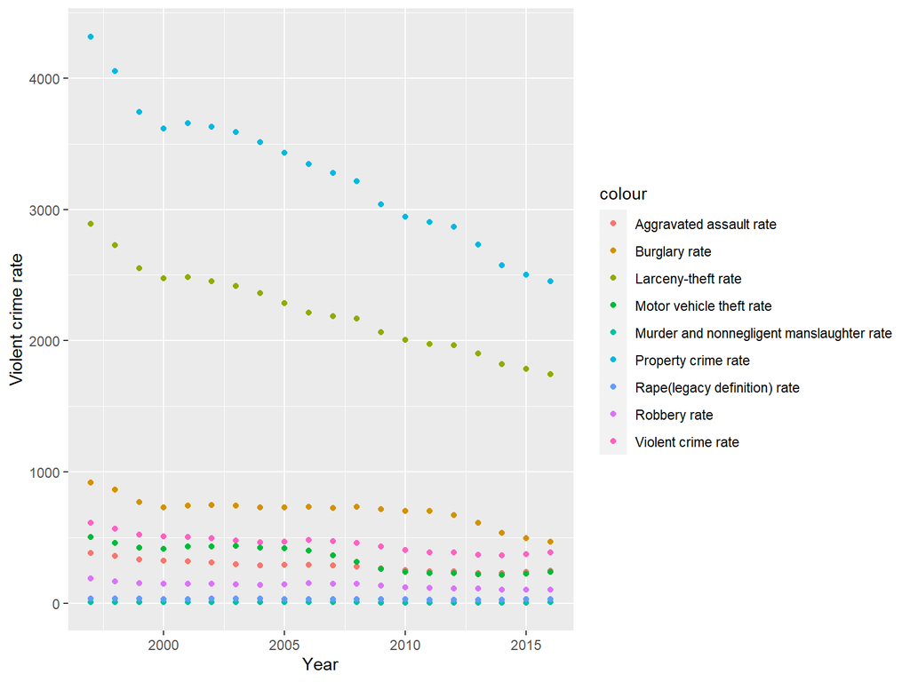

```r
ggplot(data = df, aes(x=Year)) + geom_point(aes(y = `Violent crime rate`, color = "Violent crime rate")) +
geom_point(aes(y = `Murder and nonnegligent manslaughter rate`, color = "Murder and nonnegligent manslaughter rate")) +
geom_point(aes(y = `Rape(legacy definition) rate`, color = "Rape(legacy definition) rate")) +
geom_point(aes(y = `Robbery rate`, color = "Robbery rate")) +
geom_point(aes(y = `Aggravated assault rate`, color = "Aggravated assault rate")) +
geom_point(aes(y = `Property crime rate`, color = "Property crime rate")) +
geom_point(aes(y = `Burglary rate`, color = "Burglary rate")) +
geom_point(aes(y = `Larceny-theft rate`, color = "Larceny-theft rate")) +
geom_point(aes(y = `Motor vehicle theft rate`, color = "Motor vehicle theft rate"))
```

# I visualize the results of your simple linear regression.

Add the regression line using geom_smooth() and typing in lm as method for creating the line. I used linear regression.

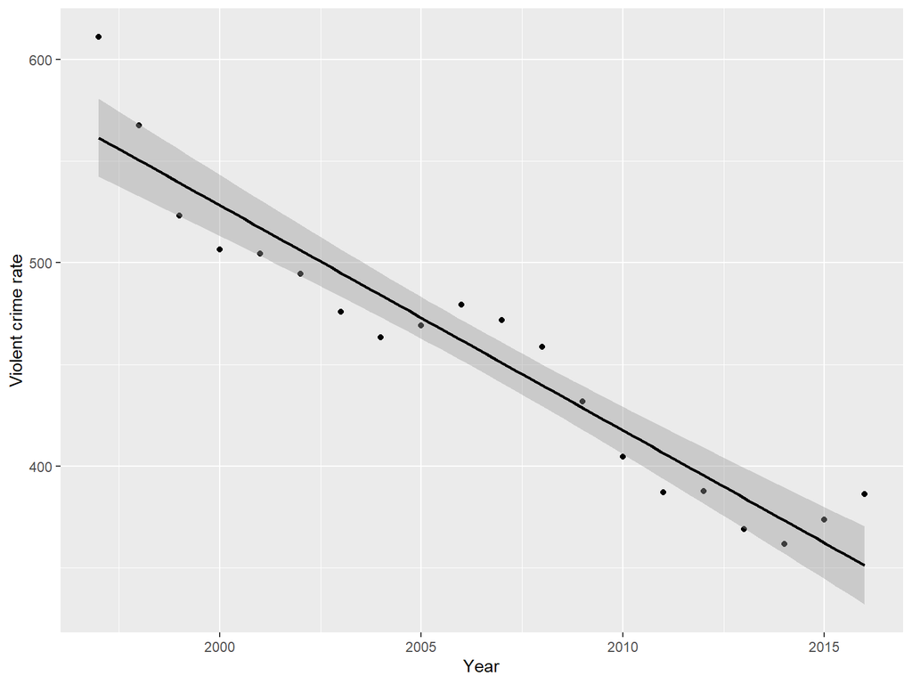

```r
df.graph<-ggplot(df, aes(x = Year, y=`Violent crime rate`)) + geom_point() + geom_smooth(method="lm", col="black")
df.graph
```

# Conclusion

Violent crime is decreasing over the years (1997-2016). We have a lover Rate per 100,000 Inhabitants in 2016 than in 1997. There is a small increase in crime from 2014 to 2016. Unfortunately FBI doesn’t publish the data belong the 2016 year.